# Supplementary Information

# 11 **Manuscript Figure 5: cross-case-study summary**

```r
# Assemble the manuscript cross-case posterior-density figure from the four joint
# 4PL case-study fits. Per-group z and CTmax draws come from the tidy-long tls()
# output (aphids, leaf, zebrafish) or the per-sex tls() objects (fly).
suppressPackageStartupMessages({
  library(ggplot2); library(dplyr); library(tibble); library(ggridges)
  library(patchwork); library(ggtext); library(cowplot); library(magick); library(here)
})

# A tls() result -> fig4 long draws + summary, relabelling CTmax to the study's
# reference (1 h here). `modcol` is the moderator column name in the tls output.
tls_to_fig4 <- function(tls_obj, modcol, case, ctmax_lab = "CTmax_1hr") {
  relab <- function(q) ifelse(q == "z", "z", ctmax_lab)
  dr <- tls_obj$draws |>
    dplyr::filter(quantity %in% c("z", "CTmax")) |>
    dplyr::transmute(case_study = case, group = as.character(.data[[modcol]]),
                     quantity = relab(quantity), value, .draw)
  sm <- tls_obj$summary |>
    dplyr::filter(quantity %in% c("z", "CTmax")) |>
    dplyr::transmute(case_study = case, group = as.character(.data[[modcol]]),
                     quantity = relab(quantity), median, lower, upper)
  list(draws = dr, summary = sm)
}

aphid_f4 <- tls_to_fig4(aphid_tls, "species",  "Cereal aphids")
leaf_f4  <- tls_to_fig4(leaf_tls,  "recovery", "Snow gum leaf PSII")
zf_f4    <- tls_to_fig4(zf_tls,    "oxygen",   "Zebrafish (oxygen)")

# Vinegar fly mortality, by sex: separate per-sex fits (absolute 4 h threshold).
fly_draws <- dplyr::bind_rows(
    Female = get_tls_est(tdt_dros_f, "draws", c("z", "CTmax")),
    Male   = get_tls_est(tdt_dros_m, "draws", c("z", "CTmax")),
    .id    = "group"
  ) |>
  dplyr::transmute(
    case_study = "Vinegar fly (mortality)",
    group,
    quantity = ifelse(quantity == "CTmax", "CTmax_4hr", "z"),
    value, .draw
  )
fly_summary <- dros_sex_sum |>
  dplyr::filter(quantity %in% c("z", "CTmax")) |>
  dplyr::transmute(
    case_study = "Vinegar fly (mortality)",
    group      = Sex,
    quantity   = ifelse(quantity == "CTmax", "CTmax_4hr", "z"),
    median, lower, upper
  )

fig4_draws <- dplyr::bind_rows(aphid_f4$draws, leaf_f4$draws, zf_f4$draws, fly_draws) |>
  dplyr::filter(is.finite(value))
# Panel a only: trim the aphid display tails to the central 98% per group so its
# axes stay tight and the contrast brackets sit cleanly (the 95% CIs are still
# drawn explicitly). Other case studies (b/c/d) are left untouched.
fig4_draws <- fig4_draws |>
  dplyr::group_by(case_study, group, quantity) |>
  dplyr::filter(case_study != "Cereal aphids" |
                (value <= stats::quantile(value, 0.99) &
                 value >= stats::quantile(value, 0.01))) |>
  dplyr::ungroup()
fig4_summary <- dplyr::bind_rows(aphid_f4$summary, leaf_f4$summary, zf_f4$summary, fly_summary)

# Persist the per-group z/CTmax medians so the manuscript can report figures
# (e.g. the CTmax_1hr range across case studies) as inline code, not magic
# numbers. Read back in ms/ms.qmd.
dir.create(here::here("output", "data"), showWarnings = FALSE, recursive = TRUE)
saveRDS(fig4_summary, here::here("output", "data", "fig4_summary.rds"))

# Facet order: z (left), CTmax (right); fly uses the 4 h CTmax reference.
fig4_draws   <- mutate(fig4_draws,   quantity = factor(quantity, levels = c("z", "CTmax_1hr", "CTmax_4hr")))
fig4_summary <- mutate(fig4_summary, quantity = factor(quantity, levels = c("z", "CTmax_1hr", "CTmax_4hr")))

# Group display order. Colour by level; the CI bar + point use a darker tone of
# the fill. Aphid species reuse the original 3-level viridis palette; snow gum
# keeps its olive, the fly its green/orange, zebrafish a blue oxygen pair.
sp_lv  <- c("M_dirhodum", "S_avenae", "R_padi")
rec_lv <- c("Dark", "Light")
oxy_lv <- c("normoxia", "hyperoxia")
vz <- viridisLite::viridis(3, begin = 0.15, end = 0.85)
fig4_pal <- c(setNames(vz, sp_lv),
              "Dark" = "#4F7942", "Light" = "#8FB07A",
              "normoxia" = "#2C7FB8", "hyperoxia" = "#7FCDBB",
              "Female" = "#009E73", "Male" = "#E69F00")
darken <- function(col, f = 0.34) { v <- grDevices::col2rgb(col) / 255 * (1 - f); grDevices::rgb(v[1], v[2], v[3]) }
fig4_pal_dark <- sapply(fig4_pal, darken)
qlab <- as_labeller(c(z = "italic(z)~(degree*C)", CTmax_1hr = "CT[max[1*hr]]~(degree*C)",
                      CTmax_4hr = "CT[max[4*hr]]~(degree*C)"), default = label_parsed)
P <- function(x) here("pics", x)

# Patrice's v2 illustrations are vector SVGs. Rasterise each to a high-resolution
# temporary PNG so the 600-dpi figure stays crisp and the existing
# draw_image()/<img> paths (which expect a raster file) work unchanged. Cached so
# each SVG is rasterised once per session.
svg_png <- local({
  cache <- new.env(parent = emptyenv())
  function(svg, width = 1600) {
    key <- paste0(svg, "@", width)
    if (is.null(cache[[key]])) {
      o <- tempfile(fileext = ".png")
      magick::image_write(magick::image_read_svg(P(svg), width = width), o)
      cache[[key]] <- o
    }
    cache[[key]]
  }
})

# Trim white margins so the aphid species illustrations are size-comparable
# (mirrors the original danio-stage y-label treatment for the 3-group panel).
aphid_src  <- c(M_dirhodum = "aphid_Mdirhodum_V2.png", S_avenae = "aphid_Savenae_V2.png", R_padi = "aphid_Rpadi_V2.png")
aphid_trim <- vapply(aphid_src, function(f) {
  o <- tempfile(fileext = ".png"); image_write(image_trim(image_read(P(f)), fuzz = 8), o); o
}, character(1))
imgH <- function(p, h) sprintf("<img src='%s' height='%d'/>", p, h)
imgW <- function(p, w) sprintf("<img src='%s' width='%d'/>", p, w)
sym  <- function(ch, pt) sprintf("<span style='font-size:%dpt'>%s</span>", pt, ch)

# pMCMC = twice the smaller posterior tail probability of the paired difference.
pmcmc <- function(d) { n <- length(d); max(2 * min(sum(d > 0) / n, sum(d < 0) / n), 1 / n) }
fmtp  <- function(p) ifelse(p < 0.001, "p<0.001", paste0("p=", sub("^0", "", sprintf("%.3f", p))))
make_brackets <- function(case, glevels, base = 0.10, step = 0.20, cbase = base, cstep = step) {
  ylev <- rev(glevels); ypos <- setNames(seq_along(ylev), ylev); prs <- combn(glevels, 2, simplify = FALSE)
  sp_all <- sapply(prs, function(pr) abs(ypos[[pr[1]]] - ypos[[pr[2]]])); maxsp <- max(sp_all)
  # x-offset keyed to the bracket's VERTICAL SPAN: adjacent-pair (inner) brackets
  # share one thin x-column and the widest (outer) bracket steps right by `step`.
  # INNER p-values print horizontally to the LEFT of their bar (tucked toward the
  # data, in the between-row gaps); the OUTER p-value prints to the RIGHT. `base`
  # offsets the inner column past the CI labels.
  dc <- filter(fig4_draws, case_study == case); rows <- list()
  for (q in as.character(unique(dc$quantity))) {
    b <- if (grepl("^CTmax", q)) cbase else base
    s <- if (grepl("^CTmax", q)) cstep else step
    dq <- filter(dc, quantity == q); rng <- range(dq$value); w <- diff(rng); tick <- 0.04 * w
    for (i in seq_along(prs)) {
      pr <- prs[[i]]; ya <- ypos[[pr[1]]]; yb <- ypos[[pr[2]]]; span <- abs(ya - yb)
      xbar <- rng[2] + w * (b + s * (span - 1))
      m <- inner_join(filter(dq, group == pr[1])[, c(".draw", "value")],
                      filter(dq, group == pr[2])[, c(".draw", "value")],
                      by = ".draw", suffix = c("_a", "_b"))
      p    <- pmcmc(m$value_a - m$value_b)
      side <- if (span == maxsp) "R" else "L"
      rows[[length(rows) + 1]] <- tibble(quantity = factor(q, levels = levels(fig4_draws$quantity)),
        x = xbar, xt = xbar - tick, side = side,
        xtext = if (side == "R") xbar + 0.04 * w else xbar - tick - 0.04 * w,
        y = min(ya, yb), yend = max(ya, yb), label = fmtp(p))
    }
  }
  bind_rows(rows)
}
add_brackets <- function(p, case, glevels, base = 0.10, step = 0.20, cbase = base, cstep = step) {
  br <- make_brackets(case, glevels, base, step, cbase, cstep)
  p + geom_segment(data = br, aes(x = x, xend = x, y = y, yend = yend), inherit.aes = FALSE, linewidth = .45, colour = "grey30") +
      geom_segment(data = br, aes(x = xt, xend = x, y = y, yend = y), inherit.aes = FALSE, linewidth = .45, colour = "grey30") +
      geom_segment(data = br, aes(x = xt, xend = x, y = yend, yend = yend), inherit.aes = FALSE, linewidth = .45, colour = "grey30") +
      geom_text(data = subset(br, side == "L"), aes(x = xtext, y = (y + yend) / 2, label = label), inherit.aes = FALSE, hjust = 1, size = 3.0, colour = "grey10", fontface = "bold") +
      geom_text(data = subset(br, side == "R"), aes(x = xtext, y = (y + yend) / 2, label = label), inherit.aes = FALSE, hjust = 0, size = 3.0, colour = "grey10", fontface = "bold")
}
fig4_panel <- function(cs, glevels, ylabels, title, sci, tag,
                       texp = 1.15, xexp_r = 0.05, xexp_l = 0.18, ridge_scale = 0.65,
                       ridge_scale_ctmax = ridge_scale) {
  d <- filter(fig4_draws,   case_study == cs) |> mutate(group = factor(group, levels = rev(glevels)))
  s <- filter(fig4_summary, case_study == cs) |> mutate(group = factor(group, levels = rev(glevels)), ci_col = fig4_pal_dark[as.character(group)])
  ggplot(d, aes(value, group, fill = group)) +
    geom_density_ridges(
      data = dplyr::filter(d, !as.character(quantity) %in% c("CTmax_1hr", "CTmax_4hr")),
      aes(height = after_stat(ndensity)), stat = "density", adjust = 2.5,
      colour = "white", linewidth = .2, alpha = .9, scale = ridge_scale,
      rel_min_height = .01
    ) +
    geom_density_ridges(
      data = dplyr::filter(d, as.character(quantity) %in% c("CTmax_1hr", "CTmax_4hr")),
      aes(height = after_stat(ndensity)), stat = "density", adjust = 2.5,
      colour = "white", linewidth = .2, alpha = .9, scale = ridge_scale_ctmax,
      rel_min_height = .01
    ) +
    geom_linerange(data = s, aes(y = group, xmin = lower, xmax = upper, colour = ci_col), inherit.aes = FALSE, linewidth = 1.3) +
    geom_point(data = s, aes(median, group, fill = group), inherit.aes = FALSE, shape = 21, colour = "black", size = 3.6, stroke = 0.7) +
    geom_label(data = s, aes(median, group, label = sprintf("%.1f [%.1f, %.1f]", median, lower, upper)), inherit.aes = FALSE, vjust = -0.7, size = 3.2, fontface = "bold", colour = "grey10", fill = alpha("white", 0.7), label.size = 0, label.padding = unit(0.08, "lines")) +
    facet_wrap(~ quantity, scales = "free_x", nrow = 1, strip.position = "bottom", labeller = labeller(quantity = qlab)) +
    scale_fill_manual(values = fig4_pal, guide = "none") + scale_colour_identity() +
    scale_x_continuous(expand = expansion(mult = c(xexp_l, xexp_r))) +
    scale_y_discrete(labels = ylabels, expand = expansion(mult = c(.06, texp))) +
    labs(x = NULL, y = NULL, title = title, subtitle = sci, tag = tag) +
    theme_classic(base_size = 13) +
    theme(strip.background = element_blank(), strip.placement = "outside", strip.text = element_text(face = "bold", size = 12),
          axis.text.y = element_markdown(), plot.tag = element_text(face = "bold", size = 16),
          plot.title = element_text(face = "bold", size = 15), plot.subtitle = element_text(face = "italic", size = 11.5, colour = "grey30"),
          panel.border = element_rect(colour = "grey75", fill = NA, linewidth = .4), plot.margin = margin(4, 4, 4, 4))
}
ins <- function(p, f, l, b, r, t) p + inset_element(ggdraw() + draw_image(f), left = l, bottom = b, right = r, top = t, align_to = "full")
```

```r
# All panel icons are placed in the central gap BETWEEN the z and CTmax facets
# (centred horizontally on the facet divider, upper-middle vertically), where
# each panel has whitespace. Top expansion (texp) is reduced accordingly, since
# the icons no longer sit above the top ridge.

# a) Cereal aphids (3 species) — species illustration + italic name as each
#    y-label, PLUS a general aphid icon raised into the top whitespace (clear of
#    the posterior ridges). Extra right expansion makes room for the three
#    right-stacked contrast brackets.
fig4_A <- add_brackets(fig4_panel("Cereal aphids", sp_lv,
            setNames(c(paste0(imgH(aphid_trim["M_dirhodum"], 40), "<br>*M. dirhodum*"),
                       paste0(imgH(aphid_trim["S_avenae"],   38), "<br>*S. avenae*"),
                       paste0(imgH(aphid_trim["R_padi"],     38), "<br>*R. padi*")), sp_lv),
            "Cereal aphids", "three species", "a)", texp = 0.50, xexp_r = 0.38, xexp_l = 0.30),
            "Cereal aphids", sp_lv, base = 0.30, step = 0.12, cbase = 0.55, cstep = 0.14)
fig4_A <- ins(fig4_A, P("aphid_Mdirhodum_V2.png"), .41, .55, .66, .95)

# b) Snow gum, dark vs light recovery. Icon enlarged ~30%.
fig4_B <- add_brackets(fig4_panel("Snow gum leaf PSII", rec_lv,
            c(Dark = "Dark", Light = "Light"), "Snow gum", "Eucalyptus pauciflora", "b)",
            texp = 0.5, xexp_r = 0.34), "Snow gum leaf PSII", rec_lv)
fig4_B <- ins(fig4_B, svg_png("snowgum_v4.svg"), .40, .52, .72, .93)

# c) Zebrafish x oxygen — LARVAL illustration raised and shrunk a touch; ridges
#    scaled DOWN (0.7) so the tight hyperoxia peaks are not so tall.
fig4_C <- add_brackets(fig4_panel("Zebrafish (oxygen)", oxy_lv,
            c(normoxia = "Normoxia", hyperoxia = "Hyperoxia"), "Zebrafish", "Danio rerio", "c)",
            texp = 0.5, xexp_r = 0.34, ridge_scale = 0.7), "Zebrafish (oxygen)", oxy_lv)
fig4_C <- ins(fig4_C, svg_png("danio_larvae_v2.svg"), .41, .54, .68, .90)

# d) Vinegar fly by sex.
fig4_D <- add_brackets(fig4_panel("Vinegar fly (mortality)", c("Female", "Male"), c(Female = sym("♀", 30), Male = sym("♂", 30)), "Vinegar fly", "Drosophila suzukii", "d)", texp = 0.5, xexp_r = 0.34), "Vinegar fly (mortality)", c("Female", "Male"))
fig4_D <- ins(fig4_D, svg_png("dros_male_v2.svg"), .44, .48, .66, .90)

fig4_final <- (fig4_A | fig4_B) / (fig4_C | fig4_D)

# Also write a standalone high-res PNG so the assembled figure can be imported
# directly (e.g. into the manuscript or slides) without re-running the chunk.
# Wider canvas (13.5 in) so the estimate labels are no longer clipped/overlapping.
dir.create(here("output", "figs"), recursive = TRUE, showWarnings = FALSE)
ggsave(here("output", "figs", "fig4_case_study_densities.png"), fig4_final,
       width = 13.5, height = 9.6, dpi = 600, bg = "white")

# Display the saved PNG rather than the live plot object, so the figure's tuned
# canvas (11.5 x 9.6 in) and inset/bracket positions are not re-flowed by the
# chunk's fig dimensions (mirrors the ms.qmd include_graphics approach).
knitr::include_graphics(here("output", "figs", "fig4_case_study_densities.png"))
```

[figure not shown]

# 12 **Manuscript Figure 6: Heat injury and survival**

Manuscript Figure 6 illustrates how a fitted joint 4PL translates a *natural* temperature trajectory into cumulative heat-injury (HI) accumulation and predicted survival, with uncertainty, for two case studies side by side: the vinegar fly (*Drosophila suzukii*, by sex) and the three cereal aphids (*Metopolophium dirhodum*, *Sitobion avenae*, *Rhopalosiphum padi*). It reuses the fly and aphid fits built above (`wf_dros_mort_F`/`wf_dros_mort_M` and `wf_aphid`) and the package’s `predict_heat_injury()`, so no model is refit here.

Repair is modelled with an **illustrative Sharpe–Schoolfield kernel that is not empirically fitted** — it shows the *qualitative* effect of repair, not a calibrated rate. We set the Arrhenius (uninhibited) rate scale to $r_{ref}=0.005$ LT50-dose h$^{-1}$; the realised repair rate is a little below this because the inactivation arms of the kernel suppress it. Bands are ±1 SE across posterior draws (not 95% credible intervals) to keep the exponential HI envelope readable. $T_{crit}$ is the relative-threshold critical temperature from each fit (per species for the aphids).

```r
# Prepare temperature traces and posterior summaries for the manuscript heat-injury figure.
## Fly: shaded hourly microclimate temperature from the Oersted et al. (2024)
## Zenodo/NicheMapR workflow (Rennes, France; Jun-Aug 2018). The cached CSV is
## built by data-raw/build_orsted_microclimate_trace.R from the original
## microclimate_injury_accumulation.R script in Zenodo record 10821572.
orsted_micro <- utils::read.csv(here::here(
  "inst", "extdata", "orsted_2024",
  "orsted2024_nichemapr_rennes_2018_hourly.csv.gz"
))
fly_trace <- orsted_micro |>
  # The column is ISO-8601 with a "T" separator and trailing "Z". as.POSIXct()'s
  # default formats do NOT match that, so it silently falls back to "%Y-%m-%d" and
  # collapses every hour of a day onto midnight (which made the Fig. 6 trace plot as
  # one vertical min-max bar per day). Give the format explicitly.
  dplyr::mutate(datetime_utc = as.POSIXct(datetime_utc,
                                          format = "%Y-%m-%dT%H:%M:%SZ", tz = "UTC")) |>
  dplyr::filter(format(datetime_utc, "%Y") == "2018",
                format(datetime_utc, "%m") %in% c("06", "07", "08"),
                is.finite(micro_temp_c)) |>
  dplyr::arrange(datetime_utc) |>
  dplyr::transmute(time = dplyr::row_number() - 1, temp = micro_temp_c,
                   datetime = datetime_utc)

## Relative-threshold T_crit per group via tls() (matches the relative HI integration).
Tc_F <- get_tls_est(tls(wf_dros_mort_F, target_surv = "relative", t_ref = 60,
                        lethal = TRUE, ndraws = 150), "summary", "Tcrit")$median
Tc_M <- get_tls_est(tls(wf_dros_mort_M, target_surv = "relative", t_ref = 60,
                        lethal = TRUE, ndraws = 150), "summary", "Tcrit")$median

## Illustrative Sharpe–Schoolfield repair kernel (doses h^-1 at TREF; NOT fitted).
## TH sets the high-temperature decline: TH = 28 puts the repair optimum near
## 26 C, comfortably below the D. suzukii T_crit (~29 C), rather than right at it.
## TREF (25 C) is only the magnitude anchor for r_ref, not the optimum.
fly_repair <- list(TA = 14065, TAL = 50000, TAH = 100000,
                   TL = 15 + 273.15, TH = 28 + 273.15,
                   TREF = 25 + 273.15, r_ref = 0.005)

ND <- 150
set.seed(123)  # reproducible posterior-draw subsample for both taxa
agg_draws <- function(hi, ...) {
  hi$draws |> dplyr::group_by(time) |>
    dplyr::summarise(hi_med = median(hi), hi_se = sd(hi),
                     surv_med = median(survival), surv_se = sd(survival),
                     .groups = "drop") |>
    dplyr::mutate(...)
}

fly_rows <- list()
for (sx in c("Female", "Male")) {
  wf <- if (sx == "Female") wf_dros_mort_F else wf_dros_mort_M
  Tc <- if (sx == "Female") Tc_F else Tc_M
  for (rep in c(FALSE, TRUE)) {
    hi <- predict_heat_injury(fly_trace[, c("time", "temp")], wf,
            target_surv = "relative", T_c = Tc, trace_unit = "hours",
            ndraws = ND, repair = rep,
            repair_pars = if (rep) fly_repair else NULL, save_draws = TRUE)
    fly_rows[[length(fly_rows) + 1]] <-
      agg_draws(hi, sex = sx, repair = ifelse(rep, "With repair", "No repair"))
  }
}
fdat <- dplyr::bind_rows(fly_rows) |> dplyr::left_join(fly_trace, by = "time")
fTc  <- mean(c(Tc_F, Tc_M))

## Aphids (d-f): UNMODIFIED hourly Wuhan air-temperature trace (no warming
## offset), all three species projected at once with by = "species". Per-species
## T_crit comes from the aphid fit; repair uses the same illustrative kernel.
## Trimmed to May-June: over the full May-Aug record the heat injury for the most
## vulnerable species (M. dirhodum, lowest T_crit) runs to ~28000% of an LT50 dose,
## swamping the axis; May-June keeps it readable and spans the window in which the
## repair model still protects the two more tolerant species (R. padi, S. avenae).
aphid_trace <- readr::read_csv(
  here::here("inst", "extdata", "data_temp_trace_aphid_summer2016.csv"),
  show_col_types = FALSE) |>
  dplyr::filter(city == "Wuhan",
                as.integer(format(datetime, "%m")) <= 6) |>   # May-June only
  # readr already parses this ISO-8601 column to POSIXct. The old as.character()
  # round-trip rendered the first (midnight) element as a bare date, which made
  # as.POSIXct() choose a date-only format for the WHOLE vector -> hours lost.
  dplyr::transmute(time = time_h, temp = temp_c, datetime = datetime)
aphid_repair <- list(TA = 14065, TAL = 50000, TAH = 100000,
                     TL = 15 + 273.15, TH = 35 + 273.15,
                     TREF = 25 + 273.15, r_ref = 0.005)
aphid_Tc <- aphid_tls$summary |> dplyr::filter(quantity == "Tcrit") |>
  dplyr::transmute(species = as.character(species), Tc = median)
aphid_rows <- list()
for (rep in c(FALSE, TRUE)) {
  hi <- predict_heat_injury(aphid_trace[, c("time", "temp")], wf_aphid,
          target_surv = "relative", trace_unit = "hours", by = "species",
          ndraws = ND, repair = rep,
          repair_pars = if (rep) aphid_repair else NULL, save_draws = TRUE)
  aphid_rows[[length(aphid_rows) + 1]] <- hi$draws |>
    dplyr::group_by(species, time) |>
    dplyr::summarise(hi_med = median(hi), hi_se = sd(hi),
                     surv_med = median(survival), surv_se = sd(survival),
                     .groups = "drop") |>
    dplyr::mutate(repair = ifelse(rep, "With repair", "No repair"))
}
adat <- dplyr::bind_rows(aphid_rows) |> dplyr::mutate(species = as.character(species)) |>
  dplyr::left_join(aphid_trace, by = "time")

dir.create(here::here("output", "data"), recursive = TRUE, showWarnings = FALSE)
saveRDS(list(fly = fdat, fly_trace = fly_trace, fly_Tc = fTc,
             aphid = adat, aphid_trace = aphid_trace, aphid_Tc = aphid_Tc,
             repair_pars = list(fly = fly_repair, aphid = aphid_repair)),
        here::here("output", "data", "fig5_hi_data.rds"))
```

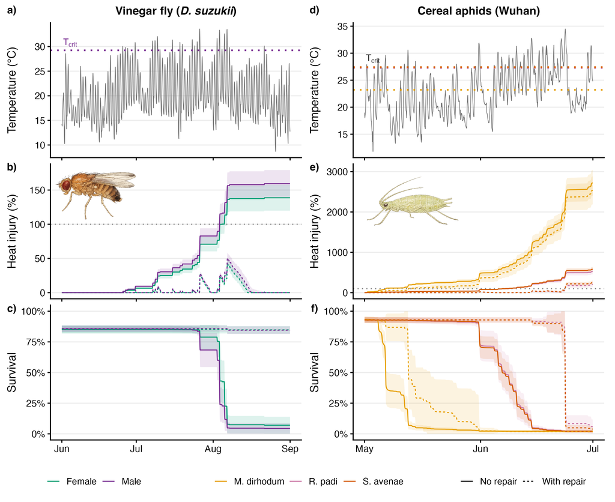

Figure S25: Manuscript Figure 6. Heat-injury accumulation and predicted survival under field temperature trajectories for the vinegar fly (*Drosophila suzukii*, by sex; panels a-c) and three cereal aphids (*Metopolophium dirhodum*, *Sitobion avenae*, *Rhopalosiphum padi*; panels d-f). (a, d) the temperature trace — shaded NicheMapR (Kearney & Porter 2017) microclimate temperature for the fly (Rennes, France, Jun–Aug 2018; Ørsted *et al.* (2024)) and the hourly air-temperature trace for the aphids (Wuhan, May–June 2016; Li *et al.* (2023), Open-Meteo ERA5 reanalysis) — with the critical temperature threshold $T_{crit}$ (dotted line). (b, e) cumulative heat injury (100% = one $LT_{50}$ dose, dotted grey) and (c, f) predicted survival, each with and without damage repair (line type). Fly panels are coloured by sex, aphid panels by species. Bands are ±1 SE across posterior draws. Predicted survival begins at each group’s fitted upper asymptote rather than at 100% (the vinegar-fly 4PL estimates a maximum survival of ≈85%, *up* < 1). Repair uses an illustrative Sharpe–Schoolfield kernel with an Arrhenius (uninhibited) rate scale $r_{ref}=0.005$ LT50-dose h$^{-1}$; it is not empirically fitted.

```r
# Build the manuscript heat-injury figure from the in-session fly + aphid data
# (fdat / adat / traces / Tc) prepared in the chunk above. svg_png() and P() are
# the icon helpers defined in the Figure 5 chunk. Fly: colour = sex; aphids:
# colour = species; line type = repair. Colours match the Figure 5 ridge panels.
fdat$repair <- factor(fdat$repair, levels = c("No repair", "With repair"))
adat$repair <- factor(adat$repair, levels = c("No repair", "With repair"))
sp_pal  <- c("M_dirhodum" = "#E69F00", "S_avenae" = "#D55E00", "R_padi" = "#CC79A7")
sp_lab  <- c(M_dirhodum = "M. dirhodum", S_avenae = "S. avenae", R_padi = "R. padi")
sex_pal <- c(Female = "#009E73", Male = "#7B3294")
tcrit_col <- "#7B3294"

f6_thm <- theme_classic(base_size = 13) +
  theme(panel.grid.major.y = element_line(colour = "grey93"), plot.margin = margin(2, 7, 2, 3),
        legend.position = "none", axis.title = element_text(size = 13), axis.text = element_text(size = 11))
f6_xsc <- function() scale_x_datetime(date_breaks = "1 month", date_labels = "%b")
f6_tg  <- function(p, lab) p + labs(tag = lab) +
  theme(plot.tag = element_text(face = "bold", size = 12), plot.tag.position = c(0.015, 0.98))

# fly temperature panel (single Tcrit line)
f6_temp1 <- function(tr, Tc, title, ylab) ggplot(tr, aes(datetime, temp)) +
  geom_line(colour = "grey45", linewidth = 0.3) +
  geom_hline(yintercept = Tc, linetype = "dotted", colour = tcrit_col, linewidth = 0.9) +
  annotate("text", x = min(tr$datetime), y = Tc, label = "T[crit]", hjust = -0.1, vjust = -0.4,
           size = 3.7, colour = tcrit_col, fontface = "bold", parse = TRUE) +
  labs(y = ylab, x = NULL, title = title) + f6_xsc() + f6_thm +
  theme(axis.text.x = element_blank(), plot.title = element_markdown(face = "bold", size = 13, hjust = 0.5))
# aphid temperature panel (per-species Tcrit lines)
f6_tempA <- function(tr, tc_df, title, ylab) ggplot(tr, aes(datetime, temp)) +
  geom_line(colour = "grey45", linewidth = 0.3) +
  geom_hline(data = tc_df, aes(yintercept = Tc, colour = species), linetype = "dotted", linewidth = 0.9, show.legend = FALSE) +
  annotate("text", x = min(tr$datetime), y = max(tc_df$Tc), label = "T[crit]", hjust = -0.1, vjust = -0.5,
           size = 3.7, colour = "grey15", fontface = "bold", parse = TRUE) +
  scale_colour_manual(values = sp_pal) +
  labs(y = ylab, x = NULL, title = title) + f6_xsc() + f6_thm +
  theme(axis.text.x = element_blank(), plot.title = element_markdown(face = "bold", size = 13, hjust = 0.5))
# fly HI / survival (colour = sex, line type = repair)
f6_hiF <- function(dd) ggplot(dd, aes(datetime, hi_med, colour = sex, fill = sex)) +
  geom_ribbon(aes(ymin = pmax(0, hi_med - hi_se), ymax = hi_med + hi_se, group = interaction(sex, repair)), colour = NA, alpha = 0.13) +
  geom_hline(yintercept = 100, linetype = "dotted", colour = "grey55") + geom_line(aes(linetype = repair), linewidth = 0.55) +
  scale_colour_manual(values = sex_pal) + scale_fill_manual(values = sex_pal, guide = "none") +
  scale_linetype_manual(values = c("No repair" = "solid", "With repair" = "22")) +
  labs(y = "Heat injury (%)", x = NULL) + f6_xsc() + f6_thm + theme(axis.text.x = element_blank())
f6_survF <- function(dd) ggplot(dd, aes(datetime, surv_med, colour = sex, fill = sex)) +
  geom_ribbon(aes(ymin = pmax(0, surv_med - surv_se), ymax = pmin(1, surv_med + surv_se), group = interaction(sex, repair)), colour = NA, alpha = 0.13) +
  geom_line(aes(linetype = repair), linewidth = 0.55) +
  scale_colour_manual(values = sex_pal) + scale_fill_manual(values = sex_pal, guide = "none") +
  scale_linetype_manual(values = c("No repair" = "solid", "With repair" = "22")) +
  scale_y_continuous(limits = c(0, 1), labels = scales::percent) + labs(y = "Survival", x = NULL) + f6_xsc() + f6_thm
# aphid HI / survival (colour = species, line type = repair)
f6_hiA <- function(dd) ggplot(dd, aes(datetime, hi_med, colour = species, fill = species)) +
  geom_ribbon(aes(ymin = pmax(0, hi_med - hi_se), ymax = hi_med + hi_se, group = interaction(species, repair)), colour = NA, alpha = 0.12) +
  geom_hline(yintercept = 100, linetype = "dotted", colour = "grey55") + geom_line(aes(linetype = repair), linewidth = 0.55) +
  scale_colour_manual(values = sp_pal, labels = sp_lab) + scale_fill_manual(values = sp_pal, guide = "none") +
  scale_linetype_manual(values = c("No repair" = "solid", "With repair" = "22")) +
  labs(y = "Heat injury (%)", x = NULL) + f6_xsc() + f6_thm + theme(axis.text.x = element_blank())
f6_survA <- function(dd) ggplot(dd, aes(datetime, surv_med, colour = species, fill = species)) +
  geom_ribbon(aes(ymin = pmax(0, surv_med - surv_se), ymax = pmin(1, surv_med + surv_se), group = interaction(species, repair)), colour = NA, alpha = 0.12) +
  geom_line(aes(linetype = repair), linewidth = 0.55) +
  scale_colour_manual(values = sp_pal, labels = sp_lab) + scale_fill_manual(values = sp_pal, guide = "none") +
  scale_linetype_manual(values = c("No repair" = "solid", "With repair" = "22")) +
  scale_y_continuous(limits = c(0, 1), labels = scales::percent) + labs(y = "Survival", x = NULL) + f6_xsc() + f6_thm
f6_ins     <- function(p, f, l, b, r, t) p + inset_element(ggdraw() + draw_image(svg_png(f)), left = l, bottom = b, right = r, top = t, align_to = "panel")
f6_ins_png <- function(p, png, l, b, r, t) p + inset_element(ggdraw() + draw_image(P(png)),     left = l, bottom = b, right = r, top = t, align_to = "panel")

fly_hi   <- f6_ins(f6_tg(f6_hiF(fdat), "b)"), "dros_male_v2.svg", .02, .55, .34, .98)
aphid_hi <- f6_ins_png(f6_tg(f6_hiA(adat), "e)"), "aphid_Mdirhodum_V2.png", .02, .46, .44, .99)
col_f <- f6_tg(f6_temp1(fly_trace,  fTc,      "Vinegar fly (*D. suzukii*)", "Temperature (°C)"), "a)") / fly_hi   / f6_tg(f6_survF(fdat), "c)")
col_a <- f6_tg(f6_tempA(aphid_trace, aphid_Tc, "Cereal aphids (Wuhan)",      "Temperature (°C)"),  "d)") / aphid_hi / f6_tg(f6_survA(adat), "f)")

mk_leg <- function(p, which) {
  g <- p + theme(legend.position = "bottom", legend.title = element_blank())
  g <- if (which == "colour") g + guides(fill = "none", linetype = "none", colour = guide_legend(order = 1))
       else g + guides(fill = "none", colour = "none", linetype = guide_legend(order = 1))
  cowplot::get_legend(g)
}
leg_fly_col <- mk_leg(f6_hiF(fdat), "colour")   # Female / Male
leg_aph_col <- mk_leg(f6_hiA(adat), "colour")   # three species
leg_repair  <- mk_leg(f6_hiA(adat), "linetype") # No repair / With repair -- shared
f6_body <- (col_f | col_a) + plot_layout(heights = c(0.5, 1, 1))
fig5_final <- cowplot::plot_grid(
  f6_body,
  cowplot::plot_grid(leg_fly_col, leg_aph_col, leg_repair, ncol = 3, rel_widths = c(1, 1.3, 1)),
  ncol = 1, rel_heights = c(1, 0.09))

ggsave(here::here("output", "figs", "fig5_heat_injury.png"), fig5_final,
       width = 9.8, height = 8.0, dpi = 300, bg = "white")

# Display the saved PNG (not the live object) so the tuned 9.8 x 8.0 in canvas
# and inset positions are not re-flowed by the chunk's fig dimensions.
knitr::include_graphics(here::here("output", "figs", "fig5_heat_injury.png"))
```

# 13 **Fitting models with `freqTLS`**

The companion package [`freqTLS`](https://github.com/itchyshin/freqTLS) fits the same models by maximum likelihood instead of MCMC, and mirrors the `bayesTLS` interface on purpose: `standardize_data()`, `fit_4pl()` and `tls()` take the same arguments and return the same tidy-long summaries — so the *same* call fits the model, only the package changes. We refit the three-species aphid model from Case Study 2 (Section 6) and compare. Because `freqTLS` deliberately shares `bayesTLS`’s function names, we call it with the `freqTLS::` prefix here so it never masks the `bayesTLS` functions used elsewhere in this supplement.

```r
# freqTLS is installed from GitHub: remotes::install_github("itchyshin/freqTLS").
# We call it with the freqTLS:: prefix (rather than library(freqTLS)) so it does
# not mask the identically named bayesTLS functions used elsewhere.

# The SAME fit_4pl() call as Case Study 2 — fit by maximum likelihood, not MCMC.
fit_aphid_freq <- freqTLS::fit_4pl(aphid_std,
                                   ctmax = ~ 0 + species, z = ~ 0 + species,
                                   k = ~ temp_c, up = ~ 1, low = ~ 1,
                                   t_ref = 60, family = freqTLS::beta_binomial_tls())

# Per-species z and CTmax, extracted exactly as with bayesTLS.
freq_sum <- freqTLS::tls(fit_aphid_freq, by = "species")$summary
freq_sum
```

```
# A tibble: 6 × 5
  species    quantity median lower upper
  <chr>      <chr>     <dbl> <dbl> <dbl>
1 M_dirhodum CTmax     35.2  35.0  35.4
2 S_avenae   CTmax     36.5  36.4  36.6
3 R_padi     CTmax     37.2  37.1  37.3
4 M_dirhodum z          4.75  4.52  5.02
5 S_avenae   z          3.61  3.46  3.77
6 R_padi     z          3.97  3.70  4.25
```

We already have the Bayesian estimates for these species from Case Study 2 (`aphid_est`). Stacking the two side by side shows they coincide (Table S35):

```r
compare <- dplyr::bind_rows(bayesTLS = aphid_est, freqTLS = freq_sum, .id = "Package") |>
  dplyr::filter(quantity %in% c("z", "CTmax")) |>
  dplyr::transmute(
    Package,
    Species  = dplyr::recode(as.character(species), M_dirhodum = "M. dirhodum",
                             R_padi = "R. padi", S_avenae = "S. avenae"),
    Quantity = dplyr::recode(quantity, z = "z (°C)", CTmax = "CTmax, 1h (°C)"),
    Estimate = format_interval(median, lower, upper, digits = 2)) |>
  dplyr::arrange(Species, Quantity, Package)

tinytable::tt(compare)
```

Table S35: Per-species thermal sensitivity ($z$) and 1-hour heat tolerance ($CT_{max,1h}$, °C) for the three aphids from the identical joint 4PL, estimated by `bayesTLS` (posterior median with 95% credible interval) and `freqTLS` (maximum-likelihood estimate with 95% profile-likelihood interval).

| Package | Species | Quantity | Estimate |
| --- | --- | --- | --- |
| bayesTLS | M. dirhodum | CTmax, 1h (°C) | 35.17 [34.96, 35.36] |
| freqTLS | M. dirhodum | CTmax, 1h (°C) | 35.22 [35.01, 35.39] |
| bayesTLS | M. dirhodum | z (°C) | 4.77 [4.53, 5.05] |
| freqTLS | M. dirhodum | z (°C) | 4.75 [4.52, 5.02] |
| bayesTLS | R. padi | CTmax, 1h (°C) | 37.15 [37.04, 37.25] |
| freqTLS | R. padi | CTmax, 1h (°C) | 37.17 [37.06, 37.28] |
| bayesTLS | R. padi | z (°C) | 3.95 [3.69, 4.25] |
| freqTLS | R. padi | z (°C) | 3.97 [3.7, 4.25] |
| bayesTLS | S. avenae | CTmax, 1h (°C) | 36.51 [36.41, 36.6] |
| freqTLS | S. avenae | CTmax, 1h (°C) | 36.53 [36.43, 36.62] |
| bayesTLS | S. avenae | z (°C) | 3.62 [3.47, 3.79] |
| freqTLS | S. avenae | z (°C) | 3.61 [3.46, 3.77] |

# 14 **Derivation of the correction factors for threshold summaries**

The manuscript states two correction factors without showing the algebra: an asymmetry correction *added* to $\text{mid}(T)$ to recover $\log_{10}t_{50}(T)$ from a 4PL whose asymptotes are not 0 and 1 (Eq. (4)), and the corresponding correction *subtracted* from the naive $CT_{max}(t_{\text{ref}})$ (Eq. (5)). Here we derive both expressions, extend them to an arbitrary survival threshold $x/100$, and check them against direct 4PL inversion.

## 14.1 Why a correction is needed

The 4PL midpoint is the $\log_{10}$-time value at which survival reaches the average of the two asymptotes, $(\text{up}+\text{low})/2$. When $\text{low}\approx0$ and $\text{up}\approx1$, this point is also near 50% survival. With partial endpoints, however, the midpoint need not occur at $p=0.5$: if $\text{up}=0.85$ and $\text{low}=0.05$, it occurs at 0.45. The absolute $\log_{10}t_{50}$ therefore comes from inverting the 4PL at $p=0.5$. The signed offset between $\text{mid}(T)$ and this absolute crossing is the **asymmetry correction**.

## 14.2 Step-by-step derivation of the $\log_{10}t_{50}$ correction

Starting from Eq. (2) of the manuscript with the temperature-dependent midpoint from Eq. (3), the survival probability is
$$p(t, T) \;=\; \text{low} \;+\; \frac{\text{up} - \text{low}}{1 + \exp\!\bigl(k\,(\log_{10}t - \text{mid}(T))\bigr)}.$$

By definition $\log_{10}t_{50}(T)$ is the value of $\log_{10}t$ at which $p = 0.5$. Solving for it gives:

**Step 1 — set $p = 0.5$:**
$$0.5 \;=\; \text{low} \;+\; \frac{\text{up} - \text{low}}{1 + \exp\!\bigl(k\,(\log_{10}t_{50}(T) - \text{mid}(T))\bigr)}.$$

**Step 2 — move $\text{low}$ to the left:**
$$0.5 - \text{low} \;=\; \frac{\text{up} - \text{low}}{1 + \exp\!\bigl(k\,(\log_{10}t_{50}(T) - \text{mid}(T))\bigr)}.$$

**Step 3 — invert both sides:**
$$\frac{1}{0.5 - \text{low}} \;=\; \frac{1 + \exp\!\bigl(k\,(\log_{10}t_{50}(T) - \text{mid}(T))\bigr)}{\text{up} - \text{low}}.$$

**Step 4 — multiply both sides by $(\text{up} - \text{low})$:**
$$\frac{\text{up} - \text{low}}{0.5 - \text{low}} \;=\; 1 + \exp\!\bigl(k\,(\log_{10}t_{50}(T) - \text{mid}(T))\bigr).$$

**Step 5 — subtract 1 to isolate the exponential:**
$$\frac{\text{up} - \text{low}}{0.5 - \text{low}} \;-\; 1 \;=\; \exp\!\bigl(k\,(\log_{10}t_{50}(T) - \text{mid}(T))\bigr).$$

The left-hand side simplifies:
$$\frac{\text{up} - \text{low}}{0.5 - \text{low}} - 1 \;=\; \frac{(\text{up} - \text{low}) - (0.5 - \text{low})}{0.5 - \text{low}} \;=\; \frac{\text{up} - 0.5}{0.5 - \text{low}}.$$

Hence
$$\frac{\text{up} - 0.5}{0.5 - \text{low}} \;=\; \exp\!\bigl(k\,(\log_{10}t_{50}(T) - \text{mid}(T))\bigr).$$

**Step 6 — take natural logs of both sides:**
$$\ln\!\left(\frac{\text{up} - 0.5}{0.5 - \text{low}}\right) \;=\; k\,\bigl(\log_{10}t_{50}(T) - \text{mid}(T)\bigr).$$

**Step 7 — divide by $k$ and add $\text{mid}(T)$:**
$$\log_{10}t_{50}(T) \;=\; \text{mid}(T) \;+\; \frac{1}{k}\ln\!\left(\frac{\text{up} - 0.5}{0.5 - \text{low}}\right).
\tag{7}$$

Thus $\log_{10}t_{50}$ is the midpoint at that temperature plus a correction that depends only on $(\text{low}, \text{up})$ and $k$, not on $T$. This is Eq. (4) of the manuscript.

**Step 8 — substitute the temperature-dependent midpoint** from Eq. (3) of the manuscript:
$$\log_{10}t_{50}(T) \;=\; \bigl[\beta_0 + \beta_1(T - \bar T)\bigr] \;+\; \frac{1}{k}\ln\!\left(\frac{\text{up} - 0.5}{0.5 - \text{low}}\right).$$

**Step 9 — distribute and group all $T$-independent terms into an intercept $\alpha$:**
$$\boxed{\quad\log_{10}t_{50}(T) \;=\; \alpha + \beta_1 T, \qquad \alpha \;=\; \beta_0 - \beta_1 \bar T \;+\; \frac{1}{k}\ln\!\left(\frac{\text{up} - 0.5}{0.5 - \text{low}}\right).\quad}
\tag{8}$$

This recovers the classical TDT relation: $\log_{10}t_{50}$ is linear in $T$.

## 14.3 From $\log_{10}t_{50}$ to the $CT_{max}$ correction

By definition, $CT_{max}(t_{\text{ref}})$ is the temperature at which $t_{50}=t_{\text{ref}}$, or $\log_{10}t_{50}(T)=\log_{10}t_{\text{ref}}$. From Equation S8:
$$\log_{10}t_{\text{ref}} \;=\; \alpha \;+\; \beta_1\,CT_{max}(t_{\text{ref}})
\quad\Longrightarrow\quad
CT_{max}(t_{\text{ref}}) \;=\; \frac{\log_{10}t_{\text{ref}} - \alpha}{\beta_1}.$$

Substituting the full $\alpha$ from Equation S8 and tidying:
$$CT_{max}(t_{\text{ref}}) \;=\; \bar T \;+\; \frac{\log_{10}t_{\text{ref}} - \beta_0}{\beta_1} \;-\; \frac{1}{\beta_1}\cdot\frac{1}{k}\ln\!\left(\frac{\text{up} - 0.5}{0.5 - \text{low}}\right).
\tag{9}$$

The first two terms are the *naive* $CT_{max}$: the temperature at which $\beta_0 + \beta_1(T-\bar T)$ crosses $\log_{10}t_{\text{ref}}$. The final term is the asymmetry correction divided by $\beta_1$, appearing as a subtraction because a vertical shift on the log-time axis becomes a horizontal temperature shift when divided by the TDT slope. This is Eq. (5) of the manuscript.

## 14.4 Generalisation to arbitrary survival thresholds $x/100$

Replacing $p = 0.5$ with $p = x/100$ gives
$$\log_{10}t_x(T) \;=\; \text{mid}(T) \;+\; \frac{1}{k}\ln\!\left(\frac{\text{up} - x/100}{x/100 - \text{low}}\right),
\tag{10}$$
which reduces to Equation S7 when $x = 50$. The correction is still added to $\text{mid}(T)$; its sign is set by the ratio inside the log. For $x < 50$ (e.g. LT10), the correction is positive and LT$_x$ occurs later than the midpoint. For $x > 50$ (e.g. LT90), it is negative and LT$_x$ occurs earlier. The corresponding $CT_{max,x}(t_{\text{ref}})$ follows by substituting this LT$_x$ correction into Equation S9.

## 14.5 The slope (and hence $z$) is robust to the correction

Because the correction in Equation S7 does not depend on $T$, it shifts $\log_{10}t_{50}(T)$ vertically without changing the slope:
$$z \;=\; -\frac{1}{\beta_1}$$
holds provided the 4PL is correctly specified. This is why the joint Bayesian 4PL and the classical two-stage pipeline can recover the same $z$ even when their $CT_{max}$ estimates differ. $CT_{max}$ has no analogous protection: the same asymmetry term enters Equation S9 divided by $\beta_1$, so errors in $\text{low}$, $\text{up}$, or $k$ shift the temperature estimate directly.

## 14.6 When the correction vanishes

When the experimental design anchors $\text{low} \approx 0$ and $\text{up} \approx 1$:
$$\frac{\text{up} - 0.5}{0.5 - \text{low}} \;\approx\; \frac{1 - 0.5}{0.5 - 0} \;=\; 1
\quad\Longrightarrow\quad
\ln\!\left(\frac{\text{up} - 0.5}{0.5 - \text{low}}\right) \;\approx\; \ln 1 \;=\; 0.$$
The correction then shrinks to zero and $\text{mid}(T)\approx\log_{10}t_{50}(T)$. This is the equivalence regime in Section 3.0.2 and Section 3.0.3, and the strict-equivalence baseline of the simulation in §3.1. The correction matters when the design is partial: sublethal endpoints, sparse survival-range coverage, or asymptotes that vary with $T$ (the last case is analysed in Section 3.0.6).

## 14.7 Numerical sanity check

The chunk below uses asymmetric asymptotes so the correction is non-zero. It checks that Equation S7 matches direct 4PL inversion at $p = 0.5$, and that Equation S9 matches the temperature obtained by direct inversion at $t_{\text{ref}}=60$ min.

```r
# Check the one-step correction against numerical inversion.
low_a  <- 0.05
up_a   <- 0.85           # asymmetric: (up - 0.5) != (0.5 - low), so the correction is non-zero
kk     <- 4
beta_0 <- log10(60)      # midpoint at T_bar sits exactly at log10(60 min)
beta_1 <- -0.25          # so z = -1/beta_1 = 4 °C
T_bar  <- 36

correction <- (1 / kk) * log((up_a - 0.5) / (0.5 - low_a))

# Closed form (eq-supp-corr-lt50) at T = 38 °C.
T_test <- 38
mid_T  <- beta_0 + beta_1 * (T_test - T_bar)
log10_LT50_closed <- mid_T + correction

# Direct numerical inversion: find log10 t such that p(t, T) = 0.5.
p_4pl <- function(log10_t, T_val) {
  midT <- beta_0 + beta_1 * (T_val - T_bar)
  low_a + (up_a - low_a) / (1 + exp(kk * (log10_t - midT)))
}
log10_LT50_direct <- stats::uniroot(
  function(x) p_4pl(x, T_test) - 0.5,
  interval = c(-5, 10)
)$root

# Closed-form CTmax_1hr from eq-supp-corr-ctmax. Because mid(T) was written
# with centred temperature, beta_0 + beta_1 * (T - T_bar), alpha converts the
# line to the uncentred form alpha + beta_1 * T before inversion.
alpha             <- beta_0 - beta_1 * T_bar + correction
CT_max_1hr_closed <- (log10(60) - alpha) / beta_1
z_from_b1         <- -1 / beta_1

# Direct cross-check for CTmax_1hr: find T such that the 4PL crosses p = 0.5
# exactly at t = 60 min.
CT_max_1hr_direct <- stats::uniroot(
  function(T_val) p_4pl(log10(60), T_val) - 0.5,
  interval = c(20, 50)
)$root

data.frame(
  Quantity = c("Asymmetry correction (1/k) log[(up-0.5)/(0.5-low)]",
               "log10(LT50) at T = 38 °C, closed form (eq-supp-corr-lt50)",
               "log10(LT50) at T = 38 °C, direct 4PL inversion",
               "  |closed - direct|",
               "z derived from beta_1 (expected: 4)",
               "CTmax_1hr, closed form (eq-supp-corr-ctmax)",
               "CTmax_1hr, direct 4PL inversion at t = 60 min",
               "  |closed - direct|"),
  Value    = c(sprintf("%+.6f", correction),
               sprintf("%.6f", log10_LT50_closed),
               sprintf("%.6f", log10_LT50_direct),
               sprintf("%.3e", abs(log10_LT50_closed - log10_LT50_direct)),
               sprintf("%.4f °C", z_from_b1),
               sprintf("%.4f °C", CT_max_1hr_closed),
               sprintf("%.4f °C", CT_max_1hr_direct),
               sprintf("%.3e", abs(CT_max_1hr_closed - CT_max_1hr_direct)))
) |>
  tinytable::tt(escape = TRUE)
```

Table S36: Verification that the closed-form $\log_{10}t_{50}$ correction (Equation S7) agrees with direct numerical inversion of the 4PL at $p = 0.5$, and that $CT_{max,1h}$ from Equation S9 agrees with direct inversion at $t = 60$ min.

| Quantity | Value |
| --- | --- |
| Asymmetry correction (1/k) log[(up-0.5)/(0.5-low)] | -0.062829 |
| log10(LT50) at T = 38 °C, closed form (eq-supp-corr-lt50) | 1.215323 |
| log10(LT50) at T = 38 °C, direct 4PL inversion | 1.215323 |
| \|closed - direct\| | 1.624e-08 |
| z derived from beta_1 (expected: 4) | 4.0000 °C |
| CTmax_1hr, closed form (eq-supp-corr-ctmax) | 35.7487 °C |
| CTmax_1hr, direct 4PL inversion at t = 60 min | 35.7487 °C |
| \|closed - direct\| | 8.151e-08 |

Here the correction is **non-zero** (-0.0628), and the closed forms match direct inversion to floating-point precision. The slope still gives $z=-1/\beta_1=4$ °C. In contrast, $CT_{max,1h}$ is shifted from $\bar T=36$ °C by about $-\text{correction}/\beta_1$, showing why the correction matters when $\text{low}$ and $\text{up}$ are not equidistant from 0.5.

# 15 **References**

Arnold, P.A., Harris, R.J., Aitken, S.M., Hoek, M.M., Cook, A.M., Leigh, A., *et al.* (2026). [Towards a standard approach to investigating the Thermal Load Sensitivity of photosystem II via chlorophyll fluorescence](https://doi.org/10.64898/2026.04.09.717599). *bioRxiv : the preprint server for biology*.

Arnold, P.A., Noble, D.W.A., Nicotra, A.B., Kearney, M.R., Rezende, E.L., Andrew, S.C., *et al.* (2025). [A framework for modelling thermal load sensitivity across life](https://doi.org/10.1111/gcb.70315). *Global Change Biology*, 31, e70315.

Faber, A.H., Møller, F.D., Ørsted, M., Ehlers, B.K. & Overgaard, J. (2026). Separating good from bad – a methodological assessment of the critical temperature that separates stressful and permissive temperatures in ectotherms.

Jørgensen, L.B., Malte, H. & Overgaard, J. (2021). [A unifying model to estimate thermal tolerance limits in ectotherms across static, dynamic and fluctuating exposures to thermal stress](https://doi.org/10.1038/s41598-021-92004-6). *Scientific Reports*, 11, 12840.

Kearney, M.R. & Porter, W.P. (2017). [NicheMapR – an R package for biophysical modelling: The microclimate model](https://doi.org/10.1111/ecog.02360). *Ecography*, 40, 664–674.

Li, Y.-J., Chen, S.-Y., Jørgensen, L.B., Overgaard, J., Renault, D., Colinet, H., *et al.* (2023). [Interspecific differences in thermal tolerance landscape explain aphid community abundance under climate change](https://doi.org/10.1016/j.jtherbio.2023.103583). *Journal of Thermal Biology*, 114, 103583.

Noble, D.W.A., Mayfield, M.M., Hoffmann, A.A., Chen, Z.-H., Lade, S.J., Bai, X., *et al.* (2026). [A systems modelling approach to predict biological responses to extreme heat](https://doi.org/10.1016/j.tree.2026.01.009). *Trends in Ecology & Evolution*, 41, 451–464.

Ørsted, M., Jørgensen, L.B. & Overgaard, J. (2022). [Finding the right thermal limit: A framework to reconcile ecological, physiological and methodological aspects of CTmax in ectotherms](https://doi.org/10.1242/jeb.244514). *Journal of Experimental Biology*, 225, jeb244514.

Ørsted, M., Willot, Q., Olsen, A.K., Kongsgaard, V. & Overgaard, J. (2024). [Thermal limits of survival and reproduction depend on stress duration: A case study of Drosophila suzukii](https://doi.org/10.1111/ele.14421). *Ecology Letters*, 27, e14421.

Rezende, E.L., Bozinovic, F., Szilágyi, A. & Santos, M. (2020). [Predicting temperature mortality and selection in natural Drosophila populations](https://doi.org/10.1126/science.aba9287). *Science*, 369, 1242–1245.

Rezende, E.L., Castañeda, L.E. & Santos, M. (2014). [Tolerance landscapes in thermal ecology](https://doi.org/10.1111/1365-2435.12268). *Functional Ecology*, 28, 799–809.

Saruhashi, S., Boerrigter, J.G.J., Hooymans, M.H.L., Sinclair, B.J. & Verberk, W.C.E.P. (2026). [Oxygen availability and oxygen delivery but not oxidative stress shape heat tolerance in diploid and triploid zebrafish larvae](https://doi.org/10.1242/jeb.251548). *Journal of Experimental Biology*, 229, jeb251548.

# 16 **Session Information**

```r
# Record package versions and session details for reproducibility.
pander::pander(sessionInfo())
```

**R version 4.5.3 (2026-03-11)**

**Platform:** aarch64-apple-darwin20

**locale:** C.UTF-8||C.UTF-8||C.UTF-8||C||C.UTF-8||C.UTF-8

**attached base packages:** *stats*, *graphics*, *grDevices*, *utils*, *datasets*, *methods* and *base*

**other attached packages:** *magick(v.2.9.1)*, *cowplot(v.1.2.0)*, *ggtext(v.0.1.2)*, *ggridges(v.0.5.7)*, *bayesTLS(v.1.0.0)*, *readxl(v.1.4.5)*, *pander(v.0.6.6)*, *patchwork(v.1.3.2)*, *tinytable(v.0.16.0)*, *tidybayes(v.3.0.7)*, *posterior(v.1.7.1)*, *brms(v.2.23.0)*, *Rcpp(v.1.1.2)*, *ggplot2(v.4.0.3)*, *purrr(v.1.2.2)*, *tibble(v.3.3.1)*, *tidyr(v.1.3.2)*, *dplyr(v.1.2.1)* and *here(v.1.0.1)*

**loaded via a namespace (and not attached):** *RColorBrewer(v.1.1-3)*, *tensorA(v.0.36.2.1)*, *jsonlite(v.2.0.0)*, *magrittr(v.2.0.5)*, *TH.data(v.1.1-3)*, *estimability(v.1.5.1)*, *farver(v.2.1.2)*, *nloptr(v.2.2.1)*, *rmarkdown(v.2.31)*, *ragg(v.1.5.2)*, *vctrs(v.0.7.3)*, *minqa(v.1.2.8)*, *htmltools(v.0.5.9)*, *distributional(v.0.8.1)*, *curl(v.7.1.0)*, *cellranger(v.1.1.0)*, *StanHeaders(v.2.36.0.9000)*, *htmlwidgets(v.1.6.4)*, *desc(v.1.4.3)*, *plyr(v.1.8.9)*, *sandwich(v.3.1-1)*, *emmeans(v.2.0.3)*, *zoo(v.1.8-14)*, *TMB(v.1.9.17)*, *commonmark(v.2.0.0)*, *lifecycle(v.1.0.5)*, *pkgconfig(v.2.0.3)*, *Matrix(v.1.7-4)*, *R6(v.2.6.1)*, *fastmap(v.1.2.0)*, *rbibutils(v.2.3)*, *digest(v.0.6.39)*, *numDeriv(v.2016.8-1.1)*, *rsvg(v.2.6.2)*, *rprojroot(v.2.1.1)*, *textshaping(v.1.0.5)*, *freqTLS(v.0.1.0)*, *labeling(v.0.4.3)*, *abind(v.1.4-8)*, *mgcv(v.1.9-4)*, *compiler(v.4.5.3)*, *remotes(v.2.5.0)*, *bit64(v.4.8.0)*, *withr(v.3.0.3)*, *S7(v.0.2.2)*, *backports(v.1.5.1)*, *inline(v.0.3.21)*, *QuickJSR(v.1.10.0)*, *pkgbuild(v.1.4.8)*, *MASS(v.7.3-65)*, *loo(v.2.10.0.9000)*, *tools(v.4.5.3)*, *otel(v.0.2.0)*, *glue(v.1.8.1)*, *callr(v.3.8.0)*, *nlme(v.3.1-168)*, *gridtext(v.0.1.5)*, *grid(v.4.5.3)*, *cmdstanr(v.0.9.0)*, *checkmate(v.2.3.4)*, *reshape2(v.1.4.5)*, *generics(v.0.1.4)*, *isoband(v.0.3.0)*, *glmmTMB(v.1.1.14)*, *gtable(v.0.3.6)*, *tzdb(v.0.5.0)*, *hms(v.1.1.4)*, *xml2(v.1.5.2)*, *utf8(v.1.2.6)*, *markdown(v.2.0)*, *pillar(v.1.11.1)*, *ggdist(v.3.3.3)*, *stringr(v.1.6.0)*, *vroom(v.1.7.1)*, *splines(v.4.5.3)*, *lattice(v.0.22-9)*, *survival(v.3.8-6)*, *bit(v.4.6.0)*, *tidyselect(v.1.2.1)*, *knitr(v.1.51)*, *reformulas(v.0.4.4)*, *arrayhelpers(v.1.1-0)*, *gridExtra(v.2.3.1)*, *V8(v.6.0.4)*, *litedown(v.0.7)*, *stats4(v.4.5.3)*, *xfun(v.0.57)*, *bridgesampling(v.1.2-1)*, *matrixStats(v.1.5.0)*, *rstan(v.2.36.0.9000)*, *stringi(v.1.8.7)*, *yaml(v.2.3.12)*, *pacman(v.0.5.1)*, *boot(v.1.3-32)*, *evaluate(v.1.0.5)*, *codetools(v.0.2-20)*, *cli(v.3.6.6)*, *RcppParallel(v.5.1.11-2)*, *systemfonts(v.1.3.2)*, *xtable(v.1.8-8)*, *Rdpack(v.2.6.4)*, *processx(v.3.9.0)*, *png(v.0.1-8)*, *coda(v.0.19-4.1)*, *svUnit(v.1.0.8)*, *parallel(v.4.5.3)*, *rstantools(v.2.6.0.9000)*, *readr(v.2.2.0)*, *bayesplot(v.1.15.0.9000)*, *Brobdingnag(v.1.2-9)*, *lme4(v.1.1-37)*, *viridisLite(v.0.4.3)*, *mvtnorm(v.1.4-1)*, *scales(v.1.4.0)*, *crayon(v.1.5.3)*, *rlang(v.1.3.0)* and *multcomp(v.1.4-28)*